# Analysis

This document contains the analyses used to replicate Vaca et al. (2011). Datasets are pulled from the `/Cleandata` directory, which were produced in the `/scripts/Cleaning.Rmd` document.

# 1 Descriptive Analysis

We will begin by exploring general descriptive statistics from our mortality data (2007-2020).

## 1.1 Total Death Count

How many deaths occurred over the study period?

```
##   total_deaths
## 1      3563541
```

## 1.2 Age-adjusted mortality rates

What are the age-adjusted mortality rates for each race/ethnicity group?

```
## # A tibble: 6 × 4
##   race_eth age_group deaths      pop
##   <chr>    <chr>      <int>    <dbl>
## 1 black    0-4         4577 4287664.
## 2 black    10-14        415 1840846.
## 3 black    15-19       2017 2306602.
## 4 black    20-24       3684 2378810.
## 5 black    25-29       3985 2318213.
## 6 black    30-34       4360 2159961.
```

```
## # A tibble: 3 × 2
##   race_eth age_adj_rate
##   <chr>           <dbl>
## 1 black            784.
## 2 hispanic         624.
## 3 white            567.
```

# 2 All cause mortality rates

## 2.1 Fig 1- Male

Male all-cause mortality rate ratios comparing Hispanic and non-Hispanic black mortality to non-Hispanic white mortality, by 5 year age groups with 95% CI, California, 2007-2020.

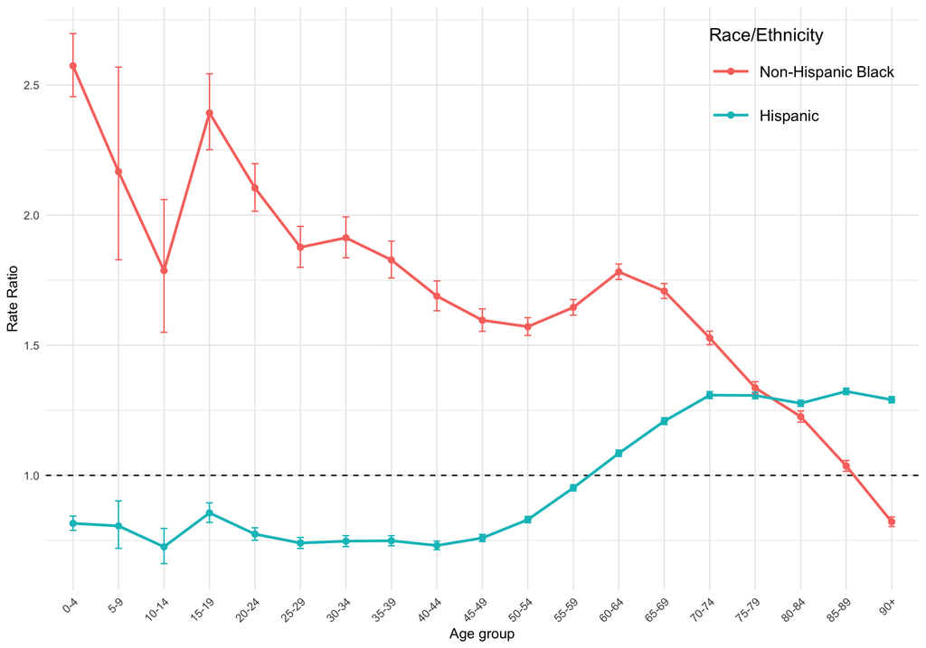

```
## # A tibble: 8 × 5
## # Groups:   race_eth, age_group [8]
##   race_eth age_group    rr rr_lcl rr_ucl
##   <chr>    <ord>     <dbl>  <dbl>  <dbl>
## 1 black    60-64     1.78   1.75   1.81
## 2 black    65-69     1.71   1.68   1.74
## 3 black    70-74     1.53   1.50   1.55
## 4 black    90+       0.822  0.804  0.841
## 5 hispanic 60-64     1.08   1.07   1.10
## 6 hispanic 65-69     1.21   1.20   1.22
## 7 hispanic 70-74     1.31   1.30   1.32
## 8 hispanic 90+       1.29   1.28   1.30
```

```
## # A tibble: 12 × 4
## # Groups:   age_group [12]
##    age_group    rr rr_lcl rr_ucl
##    <ord>     <dbl>  <dbl>  <dbl>
##  1 10-14     0.726  0.661  0.796
##  2 40-44     0.731  0.715  0.748
##  3 25-29     0.740  0.719  0.762
##  4 30-34     0.747  0.727  0.769
##  5 35-39     0.749  0.730  0.768
##  6 45-49     0.759  0.746  0.773
##  7 20-24     0.774  0.751  0.799
##  8 5-9       0.806  0.720  0.902
##  9 0-4       0.816  0.789  0.844
## 10 50-54     0.830  0.818  0.843
## 11 15-19     0.856  0.819  0.895
## 12 55-59     0.952  0.940  0.964
```

Looking through the numbers:

```
## <list_of<
##   tbl_df<
##     race_eth : character
##     age_group: ordered<0b4a0>
##     rr_ci    : character
##   >
## >[2]>
## $black
## # A tibble: 19 × 3
##    race_eth age_group rr_ci
##    <chr>    <ord>     <chr>
##  1 black    0-4       2.57 (2.45, 2.70)
##  2 black    5-9       2.17 (1.83, 2.57)
##  3 black    10-14     1.79 (1.55, 2.06)
##  4 black    15-19     2.39 (2.25, 2.54)
```

[output cut: 39 more lines]

## 2.2 Fig 2- Female

Female all cause mortality rate ratios comparing Hispanic and non-Hispanic black mortality to non-Hispanic white mortality, by 5 year age groups with 95% CI, California, 2007-2020.

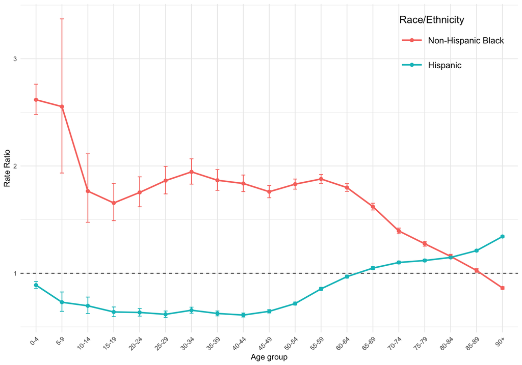

Looking through the numbers:

```
## <list_of<
##   tbl_df<
##     race_eth : character
##     age_group: ordered<0b4a0>
##     rr_ci    : character
##   >
## >[2]>
## $black
## # A tibble: 19 × 3
##    race_eth age_group rr_ci
##    <chr>    <ord>     <chr>
##  1 black    0-4       2.62 (2.48, 2.76)
##  2 black    5-9       2.55 (1.93, 3.37)
##  3 black    10-14     1.77 (1.48, 2.11)
##  4 black    15-19     1.66 (1.49, 1.84)
```

[output cut: 39 more lines]

# 3 Homicide mortality rates

## 3.1 Fig 3- Male

Male homicide mortality rates, comparing Hispanic, non-Hispanic black, and non-Latino white, 5 year age groups, California 2007-2020.

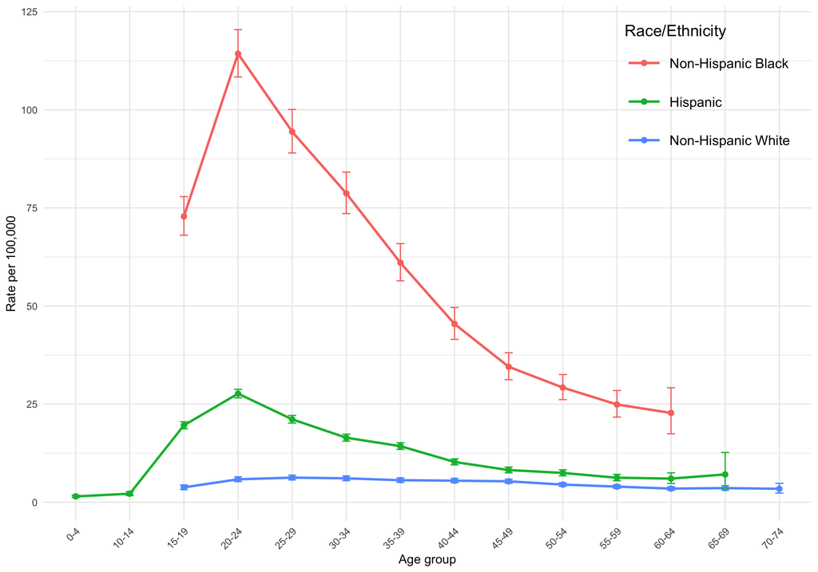

By number:

```
## <list_of<
##   tbl_df<
##     race_eth : character
##     age_group: ordered<0b4a0>
##     r_ci     : character
##   >
## >[3]>
## $black
## # A tibble: 10 × 3
##    race_eth age_group r_ci
##    <chr>    <ord>     <chr>
##  1 black    15-19     72.85 (68.06, 77.89)
##  2 black    20-24     114.29 (108.38, 120.44)
##  3 black    25-29     94.43 (89.00, 100.10)
##  4 black    30-34     78.71 (73.57, 84.12)
##  5 black    35-39     61.02 (56.43, 65.90)
##  6 black    40-44     45.43 (41.51, 49.63)
##  7 black    45-49     34.53 (31.22, 38.10)
##  8 black    50-54     29.22 (26.15, 32.55)
##  9 black    55-59     24.91 (21.69, 28.48)
## 10 black    60-64     22.76 (17.45, 29.18)
##
## $hispanic
## # A tibble: 13 × 3
##    race_eth age_group r_ci
##    <chr>    <ord>     <chr>
##  1 hispanic 0-4       1.49 (1.21, 1.81)
##  2 hispanic 10-14     2.17 (1.70, 2.73)
##  3 hispanic 15-19     19.60 (18.72, 20.52)
##  4 hispanic 20-24     27.68 (26.61, 28.79)
##  5 hispanic 25-29     21.13 (20.17, 22.13)
##  6 hispanic 30-34     16.44 (15.56, 17.35)
##  7 hispanic 35-39     14.30 (13.46, 15.18)
##  8 hispanic 40-44     10.27 (9.52, 11.05)
##  9 hispanic 45-49     8.20 (7.50, 8.96)
## 10 hispanic 50-54     7.48 (6.73, 8.28)
## 11 hispanic 55-59     6.24 (5.47, 7.10)
## 12 hispanic 60-64     6.03 (4.79, 7.49)
## 13 hispanic 65-69     7.09 (3.54, 12.68)
##
## $white
## # A tibble: 12 × 3
##    race_eth age_group r_ci
##    <chr>    <ord>     <chr>
##  1 white    15-19     3.79 (3.25, 4.40)
##  2 white    20-24     5.85 (5.27, 6.48)
##  3 white    25-29     6.28 (5.69, 6.90)
##  4 white    30-34     6.09 (5.52, 6.71)
##  5 white    35-39     5.62 (5.07, 6.21)
##  6 white    40-44     5.50 (4.97, 6.08)
##  7 white    45-49     5.34 (4.84, 5.87)
##  8 white    50-54     4.50 (4.06, 4.98)
##  9 white    55-59     3.98 (3.56, 4.44)
## 10 white    60-64     3.47 (3.05, 3.94)
## 11 white    65-69     3.61 (3.05, 4.24)
## 12 white    70-74     3.42 (2.34, 4.83)
```

# 4 All cause minus homicide

## 4.1 Figure 4: Male mortality rate ratios

Male mortality rate ratios for all causes except homicide, comparing Hispanic and non-Hispanic black mortality to non-Hispanic white mortality, by 5 year age groups with 95% CI, California, 2007-2020.

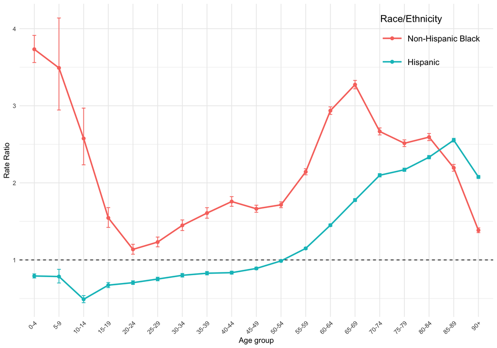

Numerically:

```
## <list_of<
##   tbl_df<
##     race_eth : character
##     age_group: ordered<0b4a0>
##     rr_ci    : character
##   >
## >[2]>
## $black
## # A tibble: 19 × 3
##    race_eth age_group rr_ci
##    <chr>    <ord>     <chr>
##  1 black    0-4       3.73 (3.56, 3.91)
##  2 black    5-9       3.49 (2.94, 4.14)
##  3 black    10-14     2.58 (2.23, 2.97)
##  4 black    15-19     1.55 (1.42, 1.68)
```

[output cut: 39 more lines]

# 5 Homicide

## 5.1 Figure 5: Male 15-24

Homicide mortality rates, among males 15-24 years of age, comparing Hispanic, non-Hispanic black, and non-Hispanic white, by year with 95% CI, California 2007-2020.

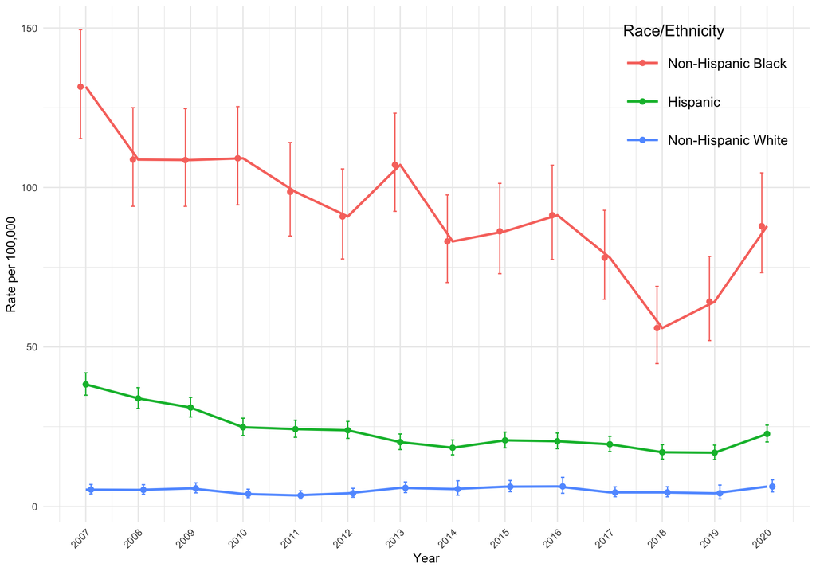

# 6 Motor vehicle

## 6.1 Figure 6: Male by age

Male motor vehicle crash mortality rates, comparing Hispanic, non-Hispanic black, and non-Hispanic white, 5 year age groups with 95% CI, California 2007-2020.

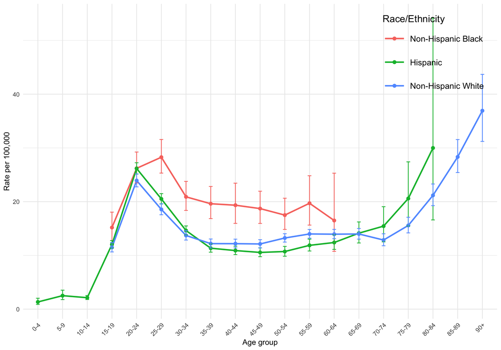

## 6.2 Figure 7: Male by year (15-24)

Motor vehicle mortality rates, among males 15-24 years of age, comparing Hispanic, non-Hispanic black, and non-Hispanic white, by year with 95% CI, California 2007-2020.

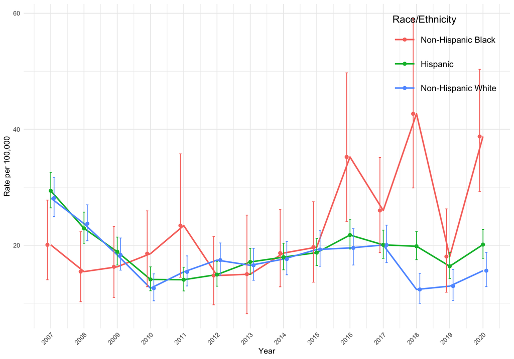